# PEC2 -Distribución normal, Intervalos de Confianza, Regresión y Contrastes de Hipótesis

# 3 **Analisis de Correlaciones**

**Matriz de correlación**

```r
carcom.select=carcom %>%
  select('Ventas', 'Valor_usado', 'Precio', 'Motor', 'Caballos', 'Ejes_distancia', 'Ancho','Longitud','PesoBruto', 'Puntuacion', 'Deposito_litro', 'Consumo_litro')
cor(carcom.select)
```

```
##                     Ventas Valor_usado      Precio       Motor   Caballos
## Ventas          1.00000000 -0.27542554 -0.25170348  0.03811139 -0.1525376
## Valor_usado    -0.27542554  1.00000000  0.95475730  0.52718729  0.7731103
## Precio         -0.25170348  0.95475730  1.00000000  0.64917095  0.8534555
## Motor           0.03811139  0.52718729  0.64917095  1.00000000  0.8616183
## Caballos       -0.15253759  0.77311034  0.85345552  0.86161827  1.0000000
## Ejes_distancia  0.40638925 -0.05467088  0.06636377  0.40881597  0.2251986
## Ancho           0.17552359  0.18142857  0.30553701  0.67228775  0.5108921
## Longitud        0.27145048  0.02577529  0.18295753  0.53697785  0.4011560
## PesoBruto       0.06718400  0.36327364  0.51139975  0.74283025  0.5986026
## Puntuacion     -0.17725690  0.82918195  0.90512353  0.84159046  0.9939494
## Deposito_litro  0.13803788  0.32474898  0.40646206  0.61689201  0.4797737
## Consumo_litro  -0.06687769 -0.39846077 -0.47953874 -0.72467766 -0.5956731
##                Ejes_distancia      Ancho    Longitud  PesoBruto Puntuacion
## Ventas             0.40638925  0.1755236  0.27145048  0.0671840 -0.1772569
## Valor_usado       -0.05467088  0.1814286  0.02577529  0.3632736  0.8291820
## Precio             0.06636377  0.3055370  0.18295753  0.5113998  0.9051235
## Motor              0.40881597  0.6722877  0.53697785  0.7428302  0.8415905
## Caballos           0.22519860  0.5108921  0.40115600  0.5986026  0.9939494
## Ejes_distancia     1.00000000  0.6760106  0.85343022  0.6752311  0.1986119
## Ancho              0.67601058  1.0000000  0.74723665  0.7357371  0.4824471
## Longitud           0.85343022  0.7472367  1.00000000  0.6849003  0.3664387
## PesoBruto          0.67523109  0.7357371  0.68490031  1.0000000  0.5984124
## Puntuacion         0.19861188  0.4824471  0.36643873  0.5984124  1.0000000
## Deposito_litro     0.65770809  0.6712508  0.56313314  0.8480066  0.4787215
## Consumo_litro     -0.46949946 -0.5978309 -0.46584948 -0.8186992 -0.5899375
##                Deposito_litro Consumo_litro
## Ventas              0.1380379   -0.06687769
## Valor_usado         0.3247490   -0.39846077
## Precio              0.4064621   -0.47953874
## Motor               0.6168920   -0.72467766
## Caballos            0.4797737   -0.59567311
## Ejes_distancia      0.6577081   -0.46949946
## Ancho               0.6712508   -0.59783091
## Longitud            0.5631331   -0.46584948
## PesoBruto           0.8480066   -0.81869920
## Puntuacion          0.4787215   -0.58993747
## Deposito_litro      1.0000000   -0.80848662
## Consumo_litro      -0.8084866    1.00000000
```

Antes de iniciar debemos tener en cuenta que el coeficiente de correlación es una medida del nivel de asociación lineal entre dos variables. Cuanto más cerca está la correlación a -1 o a +1, más lineal es su relación,es decir, más parecida es a una recta.

Un coeficiente de correlación con valor positivo indica que en el gráfico de dispersión veremos una recta ascendiente. Por el contrario, un coeficiente de correlación con valor negativo indica que en el gráfico de dispersión veremos una recta descendiente.

**NOTA:**Un coeficiente de correlación con valor cero no significa que las dos variables sean necesariamente independientes entre sí. Simplemente significa que no tienen una relación lineal, pero podrían guardar otro tipo de relación, como la exponencial o la cuadrática.

## 3.1 **Gráfico de dispersión entre “Precio” y “Puntuación”**

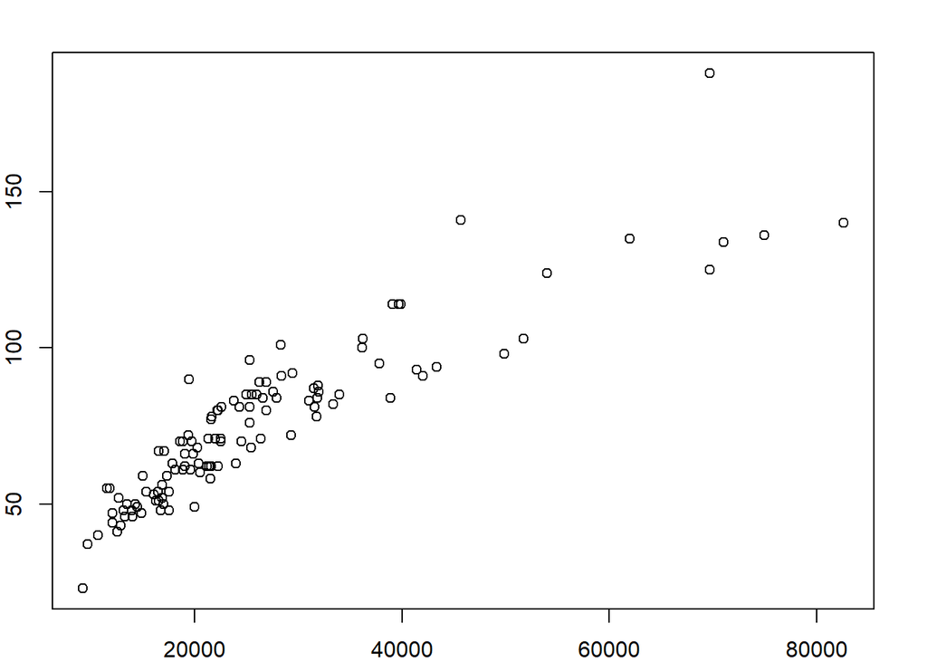

```r
par(mar=rep(2,4))
plot(carcom.select$Precio,carcom.select$Puntuacion, xlab="Precio", ylab = "Puntuación")
```

Se puede deducir del grafico de dispersion lo siguiente:

- Mientras mas alta sea la puntuacion de un vehiculo, mas alto será su precio
- Se evidencia una cocentracion de coches con un precio entre 0 y 40.000.
- Se muestran los valores outliers

```r
outliers <- boxplot.stats(carcom$Precio)$out
outliers
```

```
## [1] 62000 69725 54005 49900 69700 82600 71020 74970 51728
```

## 3.2 **Gráfico de dispersión entre “Precio” y “Ancho”.**

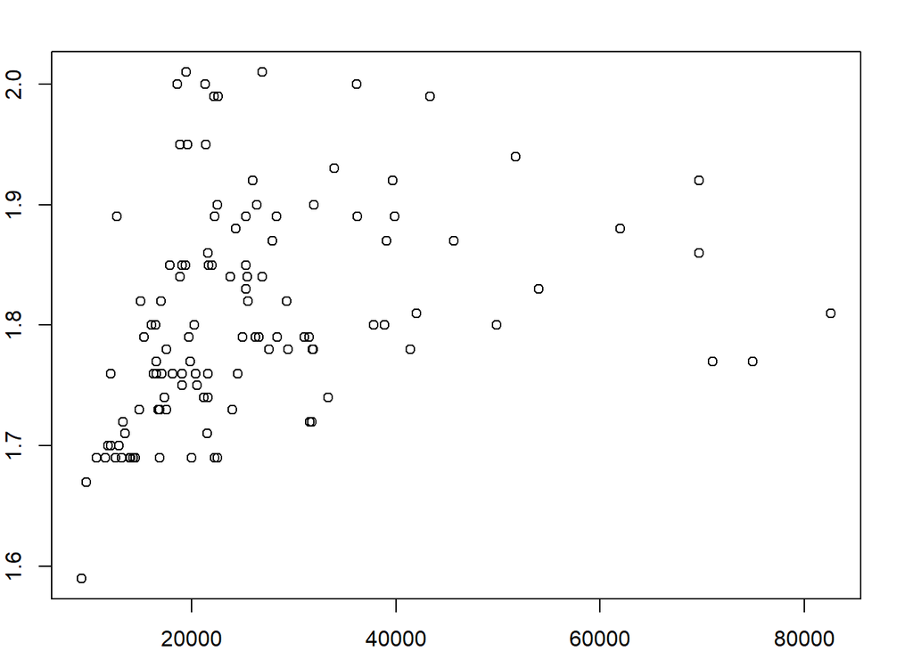

```r
par(mar=rep(2,4))
plot(carcom.select$Precio,carcom.select$Ancho)
```

**Se puede deducir lo siguiente:**

- Entre la variable Precio y Ancho la correlacion es de 0.30 por lo tanto se puede observar que es una relacion positiva y muy debil, si una variable aumenta poco afectará a la otra.